# DESeq2

Matthew Oldach

September 21, 2015

Basically, I’m just following along with the DESeq2 Manual (http://www.bioconductor.org/packages/2.13/bioc/vignettes/DESeq2/inst/doc/DESeq2.pdf), the packages Vignette, and from a 2014 MEGA workshop (https://github.com/z0on, https://github.com/rachelwright8/Ahya-White-Syndromes).

## Guide to using the DESeq2 analyis package

```r
library(DESeq2)
library(arrayQualityMetrics)
library(Biobase)
library("vsn")
```

### Read in counts and simplify sample names

#### Each gene is designated as an isogroup we only see isogroup0, isogroup1, isogroup10, isogroup100, etc. in the head(). Counts were normalized to median (or mean) counts not control genes due to legit up-regulation of abundant genes

```r
countData <- read.table("allcounts.txt")
names(countData)=sub(".sam.counts","",names(countData))
names(countData)
```

```
##  [1] "F1D3Q" "F1DFM" "F1DNM" "F1N1Q" "F1N3Q" "F1NFM" "F1NNM" "F2D3Q"
##  [9] "F2DFM" "F2DNM" "F2N1Q" "F2N3Q" "F2NFM" "F2NNM" "F3DFM" "F3DNM"
## [17] "F3N1Q" "F3N3Q" "F3NFM" "F3NNM"
```

```r
head(countData)
```

```
##               F1D3Q F1DFM F1DNM F1N1Q F1N3Q F1NFM F1NNM F2D3Q F2DFM F2DNM
## isogroup1         6     9     3     2     0     3     7     7     5     4
## isogroup10        0     0     1     0     0     0     0     1     1     0
## isogroup100       7    18     1     3     9    11    10     8     7     7
## isogroup1000      2    27     6    21     5    32    14     1    17    23
## isogroup10000     3     0    46     0     0     0     0     0     1     2
## isogroup10001    53   164    19    61   170    87    61    27    34    44
##               F2N1Q F2N3Q F2NFM F2NNM F3DFM F3DNM F3N1Q F3N3Q F3NFM F3NNM
## isogroup1         5     3     4     2     2     0     4     3     1     0
## isogroup10        2     0     0     0     0     0     0     0     0     0
## isogroup100       4     8     5     4     6     4     6     1     3     1
## isogroup1000     26     3     5    26     4    14     7     3    13    10
## isogroup10000    60     0     1     0     0     0     1     3     4   143
## isogroup10001    28   116    64    37    17    51     6    21    13    10
```

```r
write.csv(countData, "countData.csv", quote=F)
totalCounts=colSums(countData)
```

#### Total counts per sample

```r
totalCounts
```

```
##   F1D3Q   F1DFM   F1DNM   F1N1Q   F1N3Q   F1NFM   F1NNM   F2D3Q   F2DFM
## 1453783 2536648 1155904 1516181 2422117 2164573 1965200  838351 1384846
##   F2DNM   F2N1Q   F2N3Q   F2NFM   F2NNM   F3DFM   F3DNM   F3N1Q   F3N3Q
## 1623607 1534203 1765733 1143139 1436923  871014 1586063  765926  995658
##   F3NFM   F3NNM
##  678658 1151182
```

```r
min(totalCounts)
```

```
## [1] 678658
```

```r
max(totalCounts)
```

```
## [1] 2536648
```

```r
mean(totalCounts)
```

```
## [1] 1449485
```

### Construct conditions

```r
indiv= c("F1", "F1", "F1", "F1", "F1", "F1", "F1", "F2", "F2", "F2", "F2", "F2", "F2", "F2", "F3", "F3", "F3","F3", "F3", "F3")
lunar=c("3Q", "FM", "NM", "1Q","3Q", "FM", "NM", "3Q", "FM", "NM", "1Q", "3Q", "FM", "NM", "FM", "NM", "1Q", "3Q", "FM", "NM")
dayTime=c("day","day","day", "night", "night", "night", "night", "day","day","day", "night", "night", "night", "night", "day","day", "night", "night", "night", "night")
g=data.frame(indiv, lunar, dayTime)
g
```

```
##    indiv lunar dayTime
## 1     F1    3Q     day
## 2     F1    FM     day
## 3     F1    NM     day
## 4     F1    1Q   night
## 5     F1    3Q   night
## 6     F1    FM   night
## 7     F1    NM   night
## 8     F2    3Q     day
## 9     F2    FM     day
## 10    F2    NM     day
## 11    F2    1Q   night
## 12    F2    3Q   night
## 13    F2    FM   night
## 14    F2    NM   night
## 15    F3    FM     day
## 16    F3    NM     day
## 17    F3    1Q   night
## 18    F3    3Q   night
## 19    F3    FM   night
## 20    F3    NM   night
```

```r
colData<- g
```

### Make big dataframe

```r
dds<-DESeqDataSetFromMatrix(countData=countData, colData=colData, design=~lunar+dayTime)
```

## Sample Outlier Detection With arrayQualityMetrics (MEGA2014)

```r
vsd=varianceStabilizingTransformation(dds, blind=TRUE)
head(assay(vsd),10)
```

```
##                      1        2        3        4        5        6
## isogroup1     3.372518 3.238329 3.086321 2.658076 1.576167 2.672945
## isogroup10    1.576167 1.576167 2.473857 1.576167 1.576167 1.576167
## isogroup100   3.498776 3.824480 2.473857 2.886946 3.255700 3.565812
## isogroup1000  2.656200 4.227727 3.632224 4.587481 2.857395 4.637542
## isogroup10000 2.884719 1.576167 5.922616 1.576167 1.576167 1.576167
## isogroup10001 5.705539 6.431668 4.822778 5.892428 6.511250 5.863952
## isogroup10002 4.412887 4.892622 4.759942 4.786784 5.261773 5.088579
## isogroup10003 5.285290 5.175370 6.005452 5.529239 5.713882 5.188016
## isogroup10004 2.348566 2.157437 4.694171 2.658076 2.164089 2.219410
## isogroup10005 2.348566 1.576167 2.826748 1.576167 1.576167 2.219410
##                      7        8        9       10       11       12
## isogroup1     3.231378 4.004514 3.287259 2.973471 3.289031 2.752423
## isogroup10    1.576167 2.585533 2.376726 1.576167 2.695915 1.576167
## isogroup100   3.515482 4.139106 3.561199 3.378263 3.124408 3.422109
## isogroup1000  3.815754 2.585533 4.430577 4.520847 4.917266 2.752423
## isogroup10000 1.576167 1.576167 2.376726 2.582743 5.965061 1.576167
## isogroup10001 5.455629 5.548922 5.238569 5.284853 5.005500 6.440348
## isogroup10002 5.413738 4.978325 5.201880 4.658730 4.870996 5.418062
## isogroup10003 5.455629 7.011462 6.343585 6.083164 6.363339 5.677167
## isogroup10004 5.052869 6.300389 5.698993 5.227454 5.920673 5.809156
## isogroup10005 1.576167 1.576167 1.576167 1.576167 1.576167 1.576167
##                     13       14       15       16       17       18
## isogroup1     3.208087 2.689717 2.969814 1.576167 3.610010 3.146318
## isogroup10    1.576167 1.576167 1.576167 1.576167 1.576167 1.576167
## isogroup100   3.379779 3.116184 3.844135 3.040668 3.987804 2.511628
## isogroup1000  3.379779 4.903490 3.482799 4.100565 4.142914 3.146318
## isogroup10000 2.424073 1.576167 1.576167 1.576167 2.654162 3.146318
## isogroup10001 6.203195 5.331660 4.964728 5.598043 3.987804 5.042461
## isogroup10002 5.270216 4.483065 3.844135 4.982362 3.987804 4.206638
## isogroup10003 6.872613 5.331660 6.492237 4.982362 7.284148 7.165008
## isogroup10004 5.558050 4.136644 5.220514 2.331604 5.625735 6.634360
## isogroup10005 1.576167 1.576167 2.580016 2.331604 1.576167 1.576167
##                     19       20
## isogroup1     2.741913 1.576167
## isogroup10    1.576167 1.576167
## isogroup100   3.504009 2.632225
## isogroup1000  5.018172 4.476883
## isogroup10000 3.757737 7.935383
## isogroup10001 5.018172 4.476883
## isogroup10002 2.741913 3.572603
## isogroup10003 7.980378 6.340196
## isogroup10004 6.281292 5.889100
## isogroup10005 2.741913 1.576167
```

```r
e=ExpressionSet(assay(vsd), AnnotatedDataFrame(as.data.frame(colData(vsd))))
arrayQualityMetrics(e, intgroup=c("indiv", "lunar", "dayTime"), force=T)
```

```
## The directory 'arrayQualityMetrics report for e' has been created.
```

No outliers detected, moving on

# Differential Expression Analysis (DESeq2)

```r
dds <- DESeq(dds)
res<-results(dds)
summary(res)
```

```
##
## out of 67633 with nonzero total read count
## adjusted p-value < 0.1
## LFC > 0 (up)     : 13, 0.019%
## LFC < 0 (down)   : 61, 0.09%
## outliers [1]     : 1758, 2.6%
## low counts [2]   : 23431, 35%
## (mean count < 1.6)
## [1] see 'cooksCutoff' argument of ?results
## [2] see 'independentFiltering' argument of ?results
```

```r
head(res)
```

```
## log2 fold change (MAP): dayTime night vs day
## Wald test p-value: dayTime night vs day
## DataFrame with 6 rows and 6 columns
##                 baseMean log2FoldChange     lfcSE       stat    pvalue
##                <numeric>      <numeric> <numeric>  <numeric> <numeric>
## isogroup1      3.4204000     -0.4928571 0.3868858 -1.2739086 0.2026958
## isogroup10     0.2771232     -0.1979165 0.2607346 -0.7590726 0.4478091
## isogroup100    5.5290069     -0.3239185 0.3229698 -1.0029375 0.3158910
## isogroup1000  11.9751380      0.3759600 0.3065815  1.2262969 0.2200870
## isogroup10000 18.5172832      0.2789680 0.3044929  0.9161724        NA
## isogroup10001 42.2224002      0.1195042 0.2858189  0.4181117 0.6758655
##                    padj
##               <numeric>
## isogroup1     0.9997621
## isogroup10           NA
## isogroup100   0.9997621
## isogroup1000  0.9997621
## isogroup10000        NA
## isogroup10001 0.9997621
```

```r
mcols(res,use.names=TRUE)
```

```
## DataFrame with 6 rows and 2 columns
##                        type                                  description
##                 <character>                                  <character>
## baseMean       intermediate    mean of normalized counts for all samples
## log2FoldChange      results log2 fold change (MAP): dayTime night vs day
## lfcSE               results         standard error: dayTime night vs day
## stat                results         Wald statistic: dayTime night vs day
## pvalue              results      Wald test p-value: dayTime night vs day
## padj                results                         BH adjusted p-values
```

```r
write.csv(as.data.frame(res),file="results_DESeq2.csv")
```

# Visulizations

#### Create a MA plot showing DEGs (MEGA2014)

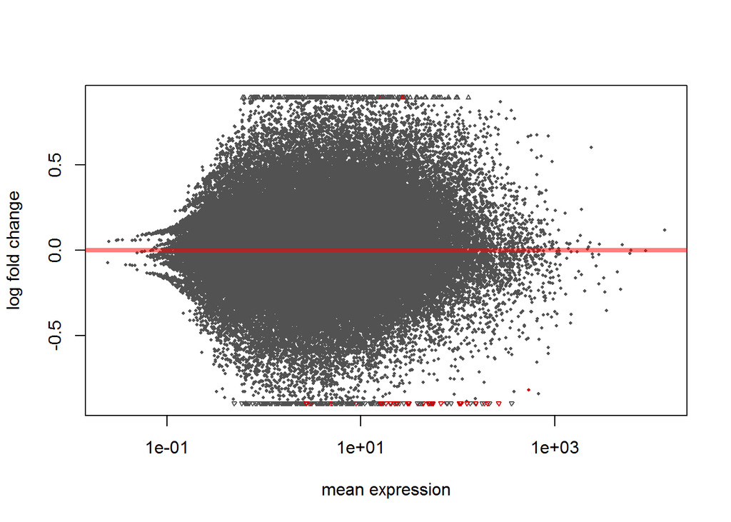

```r
plotMA(res, alpha=0.01)
```

#### plotDispEsts(dds) (MEGA2014)

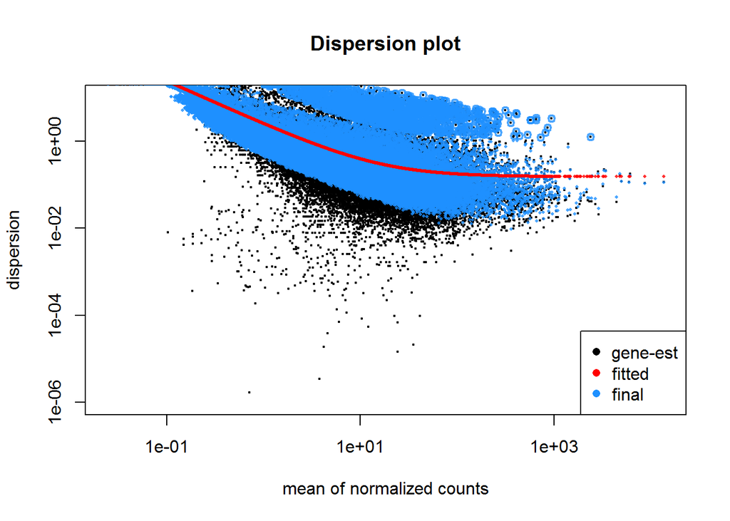

```r
plotDispEsts(dds, main="Dispersion plot", ylim = c(1e-6, 1e1) )
```

The level of dispersion is related to the biological variation seen in each treatment. As read count increases dispersion decreases, as we would expect.

However, a lot of those black dot values below the red fitted line are probably underestimates of dispersion based on the small samples sizes used (only 3 replicates values measured in this example). So, to be conservative DESeq moves all these values below the red line up to the fitted value, BUT keeps all the empirical values above the red line, even if some of these are over estimates of dispersion.

#### Plot a histogram of unadjusted p-values after filtering to look at their distribution (MEGA2014)

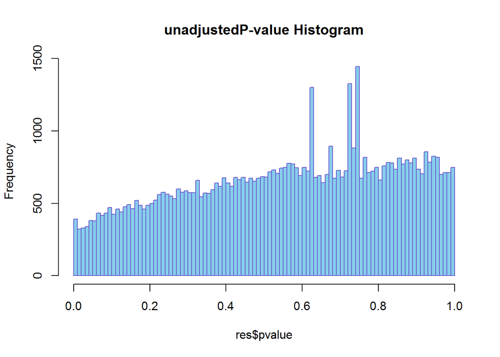

```r
hist(res$pvalue, breaks=100, col="skyblue",border="slateblue",main="unadjustedP-value Histogram")
```

The pileups in the right hand side of distribution are from very low count genes that are given discrete values.

#### Regularized log transformation for clustering/heatmaps, etc

```r
rld <- rlogTransformation(dds, blind=TRUE)
# we choose blind so that the initial conditions setting does not influence the outcome, ie we want to see if the conditions cluster based purely on the individual
head(assay(rld))
```

```
##                       1           2         3         4           5
## isogroup1      1.975761  1.85729381  1.675706  1.254509  0.44602152
## isogroup10    -2.322487 -2.34845298 -1.840689 -2.322315 -2.34749613
## isogroup100    2.494237  2.83120849  1.577468  1.889930  2.24765767
## isogroup1000   2.069915  3.58345292  3.010270  3.912187  2.16626061
## isogroup10000  1.382635 -0.03492939  4.757999  0.274194 -0.02224407
## isogroup10001  5.462532  6.08065599  4.714305  5.620966  6.14772545
##                        6           7          8          9         10
## isogroup1      1.2481988  1.84325740  2.5505296  1.8853808  1.5684808
## isogroup10    -2.3396596 -2.33804640 -1.7760308 -1.9020560 -2.3293946
## isogroup100    2.5675968  2.51603013  3.0812398  2.5542958  2.3752535
## isogroup1000   3.9677733  3.17806619  2.1695717  3.7644276  3.8541802
## isogroup10000  0.0770128  0.09652951  0.5370703  0.7747354  0.9817277
## isogroup10001  5.5986964  5.25005283  5.3281347  5.0650606  5.1038098
##                      11         12         13         14         15
## isogroup1      1.887068  1.3374347  1.8002110  1.2884600  1.5620730
## isogroup10    -1.590984 -2.3330471 -2.3133243 -2.3194364 -2.2965891
## isogroup100    2.124912  2.4200674  2.3753283  2.1164723  2.8059641
## isogroup1000   4.212113  2.1101750  2.7662471  4.2000060  2.8842277
## isogroup10000  4.815328  0.1553102  0.8486669  0.3046706  0.5319435
## isogroup10001  4.865829  6.0857837  5.8820263  5.1444225  4.8389395
##                       16        17        18        19         20
## isogroup1      0.6100033  2.154527  1.731154  1.380729  0.8381518
## isogroup10    -2.3246385 -2.289636 -2.303567 -2.282182 -2.2916287
## isogroup100    2.0376229  2.929343  1.623174  2.479386  1.7589421
## isogroup1000   3.4550052  3.481634  2.572215  4.262762  3.7867174
## isogroup10000  0.2491887  1.148958  1.695762  2.351103  6.4737503
## isogroup10001  5.3713279  4.057208  4.901551  4.890083  4.4407397
```

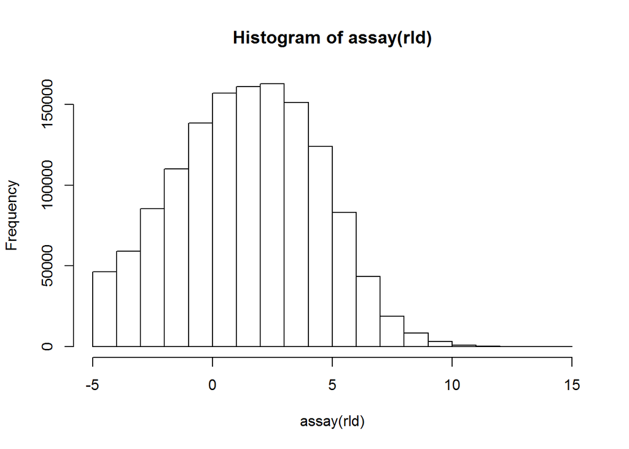

```r
hist(assay(rld))
```

####

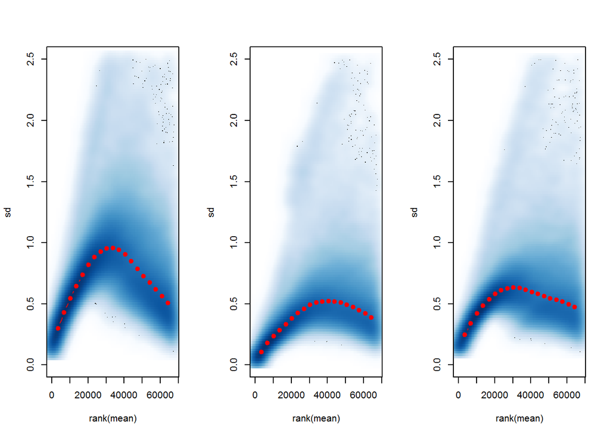

```r
par(mfrow=c(1,3))
notAllZero <- (rowSums(counts(dds))>0)
meanSdPlot(log2(counts(dds,normalized=TRUE)[notAllZero,] + 1), ylim = c(0,2.5))
meanSdPlot(assay(rld[notAllZero,]), ylim = c(0,2.5))
meanSdPlot(assay(vsd[notAllZero,]), ylim = c(0,2.5))
```

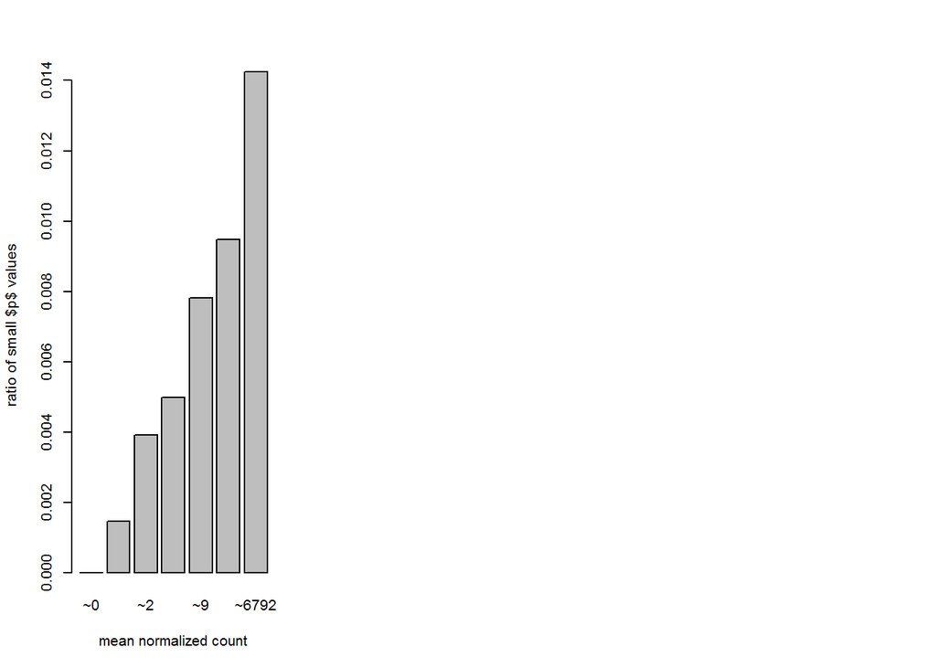

```r
qs <- c( 0, quantile( res$baseMean[res$baseMean > 0], 0:7/7 ) )
# "cut" the genes into the bins
bins <- cut( res$baseMean, qs )
# rename the levels of the bins using the middle point
levels(bins) <- paste0("~",round(.5*qs[-1] + .5*qs[-length(qs)]))
# calculate the ratio of ?p? values less than .01 for each bin
ratios <- tapply( res$pvalue, bins, function(p) mean( p < .01, na.rm=TRUE ) )
# plot these ratios
barplot(ratios, xlab="mean normalized count", ylab="ratio of small $p$ values")
```

## Use contrasts to compare levels of lunar period and the dayTime

```r
#------full moon to new moon
resAH=results(dds, contrast=c("lunar", "FM", "NM"))
table(resAH$padj<0.1)
```

```
##
## FALSE  TRUE
## 15655   481
```

```r
table(resAH$pvalue<0.05)
```

```
##
## FALSE  TRUE
## 60922  4953
```

```r
#------full moon to 1Q
resDH=results(dds, contrast=c("lunar","FM","1Q"))
table(resDH$padj<0.1)
```

```
##
## FALSE  TRUE
## 65873     2
```

```r
table(resDH$pvalue<0.05)
```

```
##
## FALSE  TRUE
## 64918   957
```

```r
#------full moon to 3Q
resDA=results(dds, contrast=c("lunar","FM","3Q"))
table(resDA$padj<0.1)
```

```
##
## FALSE  TRUE
## 36659  5785
```

```r
table(resDA$pvalue<0.05)
```

```
##
## FALSE  TRUE
## 55900  9975
```

```r
#------new moon to 3Q
resNM=results(dds, contrast=c("lunar","NM","3Q"))
table(resNM$padj<0.1)
```

```
##
## FALSE  TRUE
## 32556  3274
```

```r
table(resNM$pvalue<0.05)
```

```
##
## FALSE  TRUE
## 58437  7438
```

```r
#------new moon to 1Q
resDD=results(dds, contrast=c("lunar","NM","1Q"))
table(resDD$padj<0.1)
```

```
##
## FALSE  TRUE
## 15956   180
```

```r
table(resDD$pvalue<0.05)
```

```
##
## FALSE  TRUE
## 61955  3920
```

```r
#-----1Q to 3Q
resDV=results(dds, contrast=c("lunar","1Q","3Q"))
table(resDV$padj<0.1)
```

```
##
## FALSE  TRUE
## 39312  6443
```

```r
table(resDV$pvalue<0.05)
```

```
##
## FALSE  TRUE
## 54990 10885
```

```r
#------day to night
resDN=results(dds,contrast=c("dayTime","day","night"))
table(resDN$padj<0.1)
```

```
##
## FALSE  TRUE
## 42370    74
```

```r
table(resDN$pvalue<0.05)
```

```
##
## FALSE  TRUE
## 64115  1760
```

```r
save(dds, res, resAH, resDH, resDA, resNM, resDD, resDV, resDN, file="DESeq2Results.Rdata")
```

## Exporting and log GO

```r
vsd=getVarianceStabilizedData(dds)
head(vsd)
```

```
##                      1        2        3        4        5        6
## isogroup1     3.830145 3.724733 3.606511 3.279590 2.480325 3.290804
## isogroup10    2.480325 2.480325 3.141366 2.480325 2.480325 2.480325
## isogroup100   3.930264 4.192910 3.141366 3.453246 3.738322 3.983800
## isogroup1000  3.278176 4.527117 4.037102 4.833736 3.430693 4.877021
## isogroup10000 3.451545 2.480325 6.033993 2.480325 2.480325 2.480325
## isogroup10001 5.833021 6.512251 5.038459 6.005929 6.587798 5.979491
##                      7        8        9       10       11       12
## isogroup1     3.719300 4.340874 3.763054 3.519520 3.764444 3.350900
## isogroup10    2.480325 3.225007 3.068970 2.480325 3.308146 2.480325
## isogroup100   3.943581 4.452804 3.980107 3.834681 3.636018 3.869360
## isogroup1000  4.185790 3.225007 4.699039 4.776352 5.121564 3.350900
## isogroup10000 2.480325 2.480325 3.068970 3.222911 6.073510 2.480325
## isogroup10001 5.604177 5.689274 5.407802 5.449480 5.199617 6.520481
##                     13       14       15       16       17       18
## isogroup1     3.701114 3.303464 3.516711 2.480325 4.019244 3.653027
## isogroup10    2.480325 2.480325 2.480325 2.480325 2.480325 2.480325
## isogroup100   3.835878 3.629640 4.208967 3.571242 4.327056 3.169604
## isogroup1000  3.835878 5.109417 3.917544 4.420637 4.455988 3.653027
## isogroup10000 3.104221 2.480325 2.480325 2.480325 3.276640 3.653027
## isogroup10001 6.296478 5.491738 5.163497 5.734241 4.327056 5.232439
##                     19       20
## isogroup1     3.342938 2.480325
## isogroup10    2.480325 2.480325
## isogroup100   3.934433 3.260115
## isogroup1000  5.210862 4.738637
## isogroup10000 4.138564 7.965181
## isogroup10001 5.210862 4.738637
```

```r
colnames(vsd)=paste(g$indiv, g$lunar, g$dayTime, sep="")

###--------------get pvals from contrasts
head(resDH)
```

```
## log2 fold change (MAP): lunar FM vs 1Q
## Wald test p-value: lunar FM vs 1Q
## DataFrame with 6 rows and 6 columns
##                 baseMean log2FoldChange     lfcSE       stat    pvalue
##                <numeric>      <numeric> <numeric>  <numeric> <numeric>
## isogroup1      3.4204000     -0.4234006 0.6685555 -0.6333066 0.5265335
## isogroup10     0.2771232     -0.4208666 0.5791506 -0.7266963 0.4674120
## isogroup100    5.5290069      0.3072612 0.5363347  0.5728907 0.5667187
## isogroup1000  11.9751380     -0.1643058 0.4631542 -0.3547539 0.7227739
## isogroup10000 18.5172832     -0.6802346 0.6588790 -1.0324121        NA
## isogroup10001 42.2224002      0.6332992 0.4628072  1.3683866 0.1711911
##                    padj
##               <numeric>
## isogroup1             1
## isogroup10            1
## isogroup100           1
## isogroup1000          1
## isogroup10000        NA
## isogroup10001         1
```

```r
valsDH=cbind(resDH$pvalue, resDH$padj)
head(valsDH)
```

```
##           [,1] [,2]
## [1,] 0.5265335    1
## [2,] 0.4674120    1
## [3,] 0.5667187    1
## [4,] 0.7227739    1
## [5,]        NA   NA
## [6,] 0.1711911    1
```

```r
colnames(valsDH)=c("pvalDH", "padjDH")

head(resAH)
```

```
## log2 fold change (MAP): lunar FM vs NM
## Wald test p-value: lunar FM vs NM
## DataFrame with 6 rows and 6 columns
##                 baseMean log2FoldChange     lfcSE         stat    pvalue
##                <numeric>      <numeric> <numeric>    <numeric> <numeric>
## isogroup1      3.4204000    0.434645288 0.6082693  0.714560635 0.4748806
## isogroup10     0.2771232   -0.029677928 0.6517484 -0.045535864 0.9636802
## isogroup100    5.5290069    0.779793974 0.4463789  1.746932761 0.0806490
## isogroup1000  11.9751380   -0.001819395 0.3811510 -0.004773423 0.9961914
## isogroup10000 18.5172832   -1.398827062 0.7249758 -1.929481141        NA
## isogroup10001 42.2224002    0.566496664 0.3766842  1.503903515 0.1326062
##                    padj
##               <numeric>
## isogroup1            NA
## isogroup10           NA
## isogroup100          NA
## isogroup1000         NA
## isogroup10000        NA
## isogroup10001 0.4647898
```

```r
valsAH=cbind(resAH$pvalue, resAH$padj)
head(valsAH)
```

```
##           [,1]      [,2]
## [1,] 0.4748806        NA
## [2,] 0.9636802        NA
## [3,] 0.0806490        NA
## [4,] 0.9961914        NA
## [5,]        NA        NA
## [6,] 0.1326062 0.4647898
```

```r
colnames(valsAH)=c("pvalAH", "padjAH")

head(resDA)
```

```
## log2 fold change (MAP): lunar FM vs 3Q
## Wald test p-value: lunar FM vs 3Q
## DataFrame with 6 rows and 6 columns
##                 baseMean log2FoldChange     lfcSE        stat       pvalue
##                <numeric>      <numeric> <numeric>   <numeric>    <numeric>
## isogroup1      3.4204000     -0.1594107 0.6108334 -0.26097243 7.941138e-01
## isogroup10     0.2771232     -0.1255379 0.6371587 -0.19702769 8.438059e-01
## isogroup100    5.5290069      0.2663701 0.4467015  0.59630443 5.509719e-01
## isogroup1000  11.9751380      2.3142541 0.4740861  4.88150564 1.052789e-06
## isogroup10000 18.5172832     -0.0638829 0.7107898 -0.08987594           NA
## isogroup10001 42.2224002     -0.1957595 0.3886356 -0.50370972 6.144654e-01
##                       padj
##                  <numeric>
## isogroup1     9.330205e-01
## isogroup10              NA
## isogroup100   8.189288e-01
## isogroup1000  6.600381e-05
## isogroup10000           NA
## isogroup10001 8.539741e-01
```

```r
valsDA=cbind(resDA$pvalue, resDA$padj)
head(valsDA)
```

```
##              [,1]         [,2]
## [1,] 7.941138e-01 9.330205e-01
## [2,] 8.438059e-01           NA
## [3,] 5.509719e-01 8.189288e-01
## [4,] 1.052789e-06 6.600381e-05
## [5,]           NA           NA
## [6,] 6.144654e-01 8.539741e-01
```

```r
colnames(valsDA)=c("pvalDA", "padjDA")

head(resNM)
```

```
## log2 fold change (MAP): lunar NM vs 3Q
## Wald test p-value: lunar NM vs 3Q
## DataFrame with 6 rows and 6 columns
##                 baseMean log2FoldChange     lfcSE       stat       pvalue
##                <numeric>      <numeric> <numeric>  <numeric>    <numeric>
## isogroup1      3.4204000    -0.59405597 0.6198695 -0.9583565 3.378830e-01
## isogroup10     0.2771232    -0.09585998 0.6395869 -0.1498780 8.808609e-01
## isogroup100    5.5290069    -0.51342390 0.4689504 -1.0948362 2.735884e-01
## isogroup1000  11.9751380     2.31607346 0.4727818  4.8988214 9.641322e-07
## isogroup10000 18.5172832     1.33494417 0.7116101  1.8759489           NA
## isogroup10001 42.2224002    -0.76225620 0.3912840 -1.9480896 5.140424e-02
##                       padj
##                  <numeric>
## isogroup1     0.7083275382
## isogroup10              NA
## isogroup100   0.6509078265
## isogroup1000  0.0001016025
## isogroup10000           NA
## isogroup10001 0.2830076921
```

```r
valsNM=cbind(resNM$pvalue, resNM$padj)
head(valsNM)
```

```
##              [,1]         [,2]
## [1,] 3.378830e-01 0.7083275382
## [2,] 8.808609e-01           NA
## [3,] 2.735884e-01 0.6509078265
## [4,] 9.641322e-07 0.0001016025
## [5,]           NA           NA
## [6,] 5.140424e-02 0.2830076921
```

```r
colnames(valsNM)=c("pvalNM", "padjNM")

head(resDD)
```

```
## log2 fold change (MAP): lunar NM vs 1Q
## Wald test p-value: lunar NM vs 1Q
## DataFrame with 6 rows and 6 columns
##                 baseMean log2FoldChange     lfcSE       stat    pvalue
##                <numeric>      <numeric> <numeric>  <numeric> <numeric>
## isogroup1      3.4204000    -0.85804592 0.6753201 -1.2705766 0.2038793
## isogroup10     0.2771232    -0.39118863 0.5815756 -0.6726359 0.5011789
## isogroup100    5.5290069    -0.47253276 0.5526999 -0.8549535 0.3925769
## isogroup1000  11.9751380    -0.16248637 0.4614998 -0.3520833 0.7247758
## isogroup10000 18.5172832     0.71859244 0.6596776  1.0893085        NA
## isogroup10001 42.2224002     0.06680252 0.4647834  0.1437283 0.8857150
##                    padj
##               <numeric>
## isogroup1            NA
## isogroup10           NA
## isogroup100          NA
## isogroup1000         NA
## isogroup10000        NA
## isogroup10001 0.9771856
```

```r
valsDD=cbind(resDD$pvalue, resDD$padj)
head(valsDD)
```

```
##           [,1]      [,2]
## [1,] 0.2038793        NA
## [2,] 0.5011789        NA
## [3,] 0.3925769        NA
## [4,] 0.7247758        NA
## [5,]        NA        NA
## [6,] 0.8857150 0.9771856
```

```r
colnames(valsDD)=c("pvalDD", "padjDD")

head(resDV)
```

```
## log2 fold change (MAP): lunar 1Q vs 3Q
## Wald test p-value: lunar 1Q vs 3Q
## DataFrame with 6 rows and 6 columns
##                 baseMean log2FoldChange     lfcSE        stat       pvalue
##                <numeric>      <numeric> <numeric>   <numeric>    <numeric>
## isogroup1      3.4204000     0.26398995 0.6745652  0.39134833 6.955398e-01
## isogroup10     0.2771232     0.29532865 0.5719630  0.51634223 6.056154e-01
## isogroup100    5.5290069    -0.04089114 0.5441706 -0.07514397 9.401002e-01
## isogroup1000  11.9751380     2.47855983 0.5256158  4.71553502 2.410764e-06
## isogroup10000 18.5172832     0.61635173 0.6496926  0.94868206           NA
## isogroup10001 42.2224002    -0.82905873 0.4674088 -1.77373372 7.610721e-02
##                       padj
##                  <numeric>
## isogroup1     0.8735764894
## isogroup10              NA
## isogroup100   0.9792639827
## isogroup1000  0.0001425123
## isogroup10000           NA
## isogroup10001 0.2847563360
```

```r
valsDV=cbind(resDV$pvalue, resDV$padj)
head(valsDV)
```

```
##              [,1]         [,2]
## [1,] 6.955398e-01 0.8735764894
## [2,] 6.056154e-01           NA
## [3,] 9.401002e-01 0.9792639827
## [4,] 2.410764e-06 0.0001425123
## [5,]           NA           NA
## [6,] 7.610721e-02 0.2847563360
```

```r
colnames(valsDV)=c("pvalDV", "padjDV")

head(resDN)
```

```
## log2 fold change (MAP): dayTime day vs night
## Wald test p-value: dayTime day vs night
## DataFrame with 6 rows and 6 columns
##                 baseMean log2FoldChange     lfcSE       stat    pvalue
##                <numeric>      <numeric> <numeric>  <numeric> <numeric>
## isogroup1      3.4204000      0.4928571 0.3868858  1.2739086 0.2026958
## isogroup10     0.2771232      0.1979165 0.2607346  0.7590726 0.4478091
## isogroup100    5.5290069      0.3239185 0.3229698  1.0029375 0.3158910
## isogroup1000  11.9751380     -0.3759600 0.3065815 -1.2262969 0.2200870
## isogroup10000 18.5172832     -0.2789680 0.3044929 -0.9161724        NA
## isogroup10001 42.2224002     -0.1195042 0.2858189 -0.4181117 0.6758655
##                    padj
##               <numeric>
## isogroup1     0.9997621
## isogroup10           NA
## isogroup100   0.9997621
## isogroup1000  0.9997621
## isogroup10000        NA
## isogroup10001 0.9997621
```

```r
valsDN=cbind(resDN$pvalue, resDN$padj)
head(valsDN)
```

```
##           [,1]      [,2]
## [1,] 0.2026958 0.9997621
## [2,] 0.4478091        NA
## [3,] 0.3158910 0.9997621
## [4,] 0.2200870 0.9997621
## [5,]        NA        NA
## [6,] 0.6758655 0.9997621
```

```r
colnames(valsDN)=c("pvalDN","padjDN")

results=cbind(valsDH,valsAH,valsDA,valsNM,valsDD,valsDV,valsDN)
head(results)
```

```
##         pvalDH padjDH    pvalAH    padjAH       pvalDA       padjDA
## [1,] 0.5265335      1 0.4748806        NA 7.941138e-01 9.330205e-01
## [2,] 0.4674120      1 0.9636802        NA 8.438059e-01           NA
## [3,] 0.5667187      1 0.0806490        NA 5.509719e-01 8.189288e-01
## [4,] 0.7227739      1 0.9961914        NA 1.052789e-06 6.600381e-05
## [5,]        NA     NA        NA        NA           NA           NA
## [6,] 0.1711911      1 0.1326062 0.4647898 6.144654e-01 8.539741e-01
##            pvalNM       padjNM    pvalDD    padjDD       pvalDV
## [1,] 3.378830e-01 0.7083275382 0.2038793        NA 6.955398e-01
## [2,] 8.808609e-01           NA 0.5011789        NA 6.056154e-01
## [3,] 2.735884e-01 0.6509078265 0.3925769        NA 9.401002e-01
## [4,] 9.641322e-07 0.0001016025 0.7247758        NA 2.410764e-06
## [5,]           NA           NA        NA        NA           NA
## [6,] 5.140424e-02 0.2830076921 0.8857150 0.9771856 7.610721e-02
##            padjDV    pvalDN    padjDN
## [1,] 0.8735764894 0.2026958 0.9997621
## [2,]           NA 0.4478091        NA
## [3,] 0.9792639827 0.3158910 0.9997621
## [4,] 0.0001425123 0.2200870 0.9997621
## [5,]           NA        NA        NA
## [6,] 0.2847563360 0.6758655 0.9997621
```

#### Explore Contrasts

```r
######-------------make vsd and pvals table
vsdpvals=cbind(vsd,results)
head(vsdpvals)
```

```
##                F13Qday  F1FMday  F1NMday F11Qnight F13Qnight F1FMnight
## isogroup1     3.830145 3.724733 3.606511  3.279590  2.480325  3.290804
## isogroup10    2.480325 2.480325 3.141366  2.480325  2.480325  2.480325
## isogroup100   3.930264 4.192910 3.141366  3.453246  3.738322  3.983800
## isogroup1000  3.278176 4.527117 4.037102  4.833736  3.430693  4.877021
## isogroup10000 3.451545 2.480325 6.033993  2.480325  2.480325  2.480325
## isogroup10001 5.833021 6.512251 5.038459  6.005929  6.587798  5.979491
##               F1NMnight  F23Qday  F2FMday  F2NMday F21Qnight F23Qnight
## isogroup1      3.719300 4.340874 3.763054 3.519520  3.764444  3.350900
## isogroup10     2.480325 3.225007 3.068970 2.480325  3.308146  2.480325
## isogroup100    3.943581 4.452804 3.980107 3.834681  3.636018  3.869360
## isogroup1000   4.185790 3.225007 4.699039 4.776352  5.121564  3.350900
## isogroup10000  2.480325 2.480325 3.068970 3.222911  6.073510  2.480325
## isogroup10001  5.604177 5.689274 5.407802 5.449480  5.199617  6.520481
##               F2FMnight F2NMnight  F3FMday  F3NMday F31Qnight F33Qnight
## isogroup1      3.701114  3.303464 3.516711 2.480325  4.019244  3.653027
## isogroup10     2.480325  2.480325 2.480325 2.480325  2.480325  2.480325
## isogroup100    3.835878  3.629640 4.208967 3.571242  4.327056  3.169604
## isogroup1000   3.835878  5.109417 3.917544 4.420637  4.455988  3.653027
## isogroup10000  3.104221  2.480325 2.480325 2.480325  3.276640  3.653027
## isogroup10001  6.296478  5.491738 5.163497 5.734241  4.327056  5.232439
##               F3FMnight F3NMnight    pvalDH padjDH    pvalAH    padjAH
## isogroup1      3.342938  2.480325 0.5265335      1 0.4748806        NA
## isogroup10     2.480325  2.480325 0.4674120      1 0.9636802        NA
## isogroup100    3.934433  3.260115 0.5667187      1 0.0806490        NA
## isogroup1000   5.210862  4.738637 0.7227739      1 0.9961914        NA
## isogroup10000  4.138564  7.965181        NA     NA        NA        NA
## isogroup10001  5.210862  4.738637 0.1711911      1 0.1326062 0.4647898
##                     pvalDA       padjDA       pvalNM       padjNM
## isogroup1     7.941138e-01 9.330205e-01 3.378830e-01 0.7083275382
## isogroup10    8.438059e-01           NA 8.808609e-01           NA
## isogroup100   5.509719e-01 8.189288e-01 2.735884e-01 0.6509078265
## isogroup1000  1.052789e-06 6.600381e-05 9.641322e-07 0.0001016025
## isogroup10000           NA           NA           NA           NA
## isogroup10001 6.144654e-01 8.539741e-01 5.140424e-02 0.2830076921
##                  pvalDD    padjDD       pvalDV       padjDV    pvalDN
## isogroup1     0.2038793        NA 6.955398e-01 0.8735764894 0.2026958
## isogroup10    0.5011789        NA 6.056154e-01           NA 0.4478091
## isogroup100   0.3925769        NA 9.401002e-01 0.9792639827 0.3158910
## isogroup1000  0.7247758        NA 2.410764e-06 0.0001425123 0.2200870
## isogroup10000        NA        NA           NA           NA        NA
## isogroup10001 0.8857150 0.9771856 7.610721e-02 0.2847563360 0.6758655
##                  padjDN
## isogroup1     0.9997621
## isogroup10           NA
## isogroup100   0.9997621
## isogroup1000  0.9997621
## isogroup10000        NA
## isogroup10001 0.9997621
```

```r
write.csv(vsdpvals, "VSDandPVALS_lunar.csv", quote=F)
VSD_PVals=read.csv("VSDandPVALS_lunar.csv")
```

#### —————get data for WGCNA

```r
head(vsdpvals)
```

```
##                F13Qday  F1FMday  F1NMday F11Qnight F13Qnight F1FMnight
## isogroup1     3.830145 3.724733 3.606511  3.279590  2.480325  3.290804
## isogroup10    2.480325 2.480325 3.141366  2.480325  2.480325  2.480325
## isogroup100   3.930264 4.192910 3.141366  3.453246  3.738322  3.983800
## isogroup1000  3.278176 4.527117 4.037102  4.833736  3.430693  4.877021
## isogroup10000 3.451545 2.480325 6.033993  2.480325  2.480325  2.480325
## isogroup10001 5.833021 6.512251 5.038459  6.005929  6.587798  5.979491
##               F1NMnight  F23Qday  F2FMday  F2NMday F21Qnight F23Qnight
## isogroup1      3.719300 4.340874 3.763054 3.519520  3.764444  3.350900
## isogroup10     2.480325 3.225007 3.068970 2.480325  3.308146  2.480325
## isogroup100    3.943581 4.452804 3.980107 3.834681  3.636018  3.869360
## isogroup1000   4.185790 3.225007 4.699039 4.776352  5.121564  3.350900
## isogroup10000  2.480325 2.480325 3.068970 3.222911  6.073510  2.480325
## isogroup10001  5.604177 5.689274 5.407802 5.449480  5.199617  6.520481
##               F2FMnight F2NMnight  F3FMday  F3NMday F31Qnight F33Qnight
## isogroup1      3.701114  3.303464 3.516711 2.480325  4.019244  3.653027
## isogroup10     2.480325  2.480325 2.480325 2.480325  2.480325  2.480325
## isogroup100    3.835878  3.629640 4.208967 3.571242  4.327056  3.169604
## isogroup1000   3.835878  5.109417 3.917544 4.420637  4.455988  3.653027
## isogroup10000  3.104221  2.480325 2.480325 2.480325  3.276640  3.653027
## isogroup10001  6.296478  5.491738 5.163497 5.734241  4.327056  5.232439
##               F3FMnight F3NMnight    pvalDH padjDH    pvalAH    padjAH
## isogroup1      3.342938  2.480325 0.5265335      1 0.4748806        NA
## isogroup10     2.480325  2.480325 0.4674120      1 0.9636802        NA
## isogroup100    3.934433  3.260115 0.5667187      1 0.0806490        NA
## isogroup1000   5.210862  4.738637 0.7227739      1 0.9961914        NA
## isogroup10000  4.138564  7.965181        NA     NA        NA        NA
## isogroup10001  5.210862  4.738637 0.1711911      1 0.1326062 0.4647898
##                     pvalDA       padjDA       pvalNM       padjNM
## isogroup1     7.941138e-01 9.330205e-01 3.378830e-01 0.7083275382
## isogroup10    8.438059e-01           NA 8.808609e-01           NA
## isogroup100   5.509719e-01 8.189288e-01 2.735884e-01 0.6509078265
## isogroup1000  1.052789e-06 6.600381e-05 9.641322e-07 0.0001016025
## isogroup10000           NA           NA           NA           NA
## isogroup10001 6.144654e-01 8.539741e-01 5.140424e-02 0.2830076921
##                  pvalDD    padjDD       pvalDV       padjDV    pvalDN
## isogroup1     0.2038793        NA 6.955398e-01 0.8735764894 0.2026958
## isogroup10    0.5011789        NA 6.056154e-01           NA 0.4478091
## isogroup100   0.3925769        NA 9.401002e-01 0.9792639827 0.3158910
## isogroup1000  0.7247758        NA 2.410764e-06 0.0001425123 0.2200870
## isogroup10000        NA        NA           NA           NA        NA
## isogroup10001 0.8857150 0.9771856 7.610721e-02 0.2847563360 0.6758655
##                  padjDN
## isogroup1     0.9997621
## isogroup10           NA
## isogroup100   0.9997621
## isogroup1000  0.9997621
## isogroup10000        NA
## isogroup10001 0.9997621
```

```r
vsdp=as.data.frame(vsdpvals)

AH01=vsdp[vsdp$pvalAH<0.1 & !is.na(vsdp$pvalAH),]
length(AH01[,1])
```

```
## [1] 8375
```

```r
DA01=vsdp[vsdp$pvalDA<0.1 & !is.na(vsdp$pvalDA),]
length(DA01[,1])
```

```
## [1] 13749
```

```r
DH01=vsdp[vsdp$pvalDH<0.1 & !is.na(vsdp$pvalDH),]
length(DH01[,1])
```

```
## [1] 2451
```

```r
NM01=vsdp[vsdp$pvalNM<0.1 & !is.na(vsdp$pvalNM),]
length(NM01[,1])
```

```
## [1] 10862
```

```r
DD01=vsdp[vsdp$pvalDD<0.1 & !is.na(vsdp$pvalDD),]
length(DD01[,1])
```

```
## [1] 7008
```

```r
DV01=vsdp[vsdp$pvalDV<0.1 & !is.na(vsdp$pvalDV),]
length(DV01[,1])
```

```
## [1] 15060
```

```r
DN01=vsdp[vsdp$pvalDN<0.1 & !is.na(vsdp$pvalDN),]
length(DN01[,1])
```

```
## [1] 3890
```

```r
degs01=union(row.names(AH01),row.names(DA01))
degs01=union(degs01,row.names(DH01))
degs01=union(degs01,row.names(NM01))
degs01=union(degs01,row.names(DD01))
degs01=union(degs01,row.names(DV01))
degs01=union(degs01,row.names(DN01))
length(degs01)
```

```
## [1] 27720
```

```r
wdegs01=vsd[(row.names(vsd) %in% degs01),]
head(wdegs01)
```

```
##                F13Qday  F1FMday  F1NMday F11Qnight F13Qnight F1FMnight
## isogroup100   3.930264 4.192910 3.141366  3.453246  3.738322  3.983800
## isogroup1000  3.278176 4.527117 4.037102  4.833736  3.430693  4.877021
## isogroup10001 5.833021 6.512251 5.038459  6.005929  6.587798  5.979491
## isogroup10003 5.449875 5.351069 6.111181  5.671287  5.840709  5.362406
## isogroup10006 8.330001 8.275424 7.990071  8.087231  7.863830  7.903466
## isogroup10008 4.459380 3.080953 3.606511  3.049056  3.862146  3.517953
##               F1NMnight  F23Qday  F2FMday  F2NMday F21Qnight F23Qnight
## isogroup100    3.943581 4.452804 3.980107 3.834681  3.636018  3.869360
## isogroup1000   4.185790 3.225007 4.699039 4.776352  5.121564  3.350900
## isogroup10001  5.604177 5.689274 5.407802 5.449480  5.199617  6.520481
## isogroup10003  5.604177 7.066676 6.428861 6.183833  6.447542  5.806900
## isogroup10006  8.203552 8.500693 8.451924 8.074064  7.976068  8.008303
## isogroup10008  3.428777 3.225007 3.486461 3.384983  3.069640  3.350900
##               F2FMnight F2NMnight  F3FMday  F3NMday F31Qnight F33Qnight
## isogroup100    3.835878  3.629640 4.208967 3.571242  4.327056  3.169604
## isogroup1000   3.835878  5.109417 3.917544 4.420637  4.455988  3.653027
## isogroup10001  6.296478  5.491738 5.163497 5.734241  4.327056  5.232439
## isogroup10003  6.933106  5.491738 6.569732 5.179108  7.330244  7.214896
## isogroup10006  7.975249  7.992091 7.829297 8.254920  7.164549  6.825827
## isogroup10008  3.104221  3.629640 3.516711 3.260681  3.827659  3.169604
##               F3FMnight F3NMnight
## isogroup100    3.934433  3.260115
## isogroup1000   5.210862  4.738637
## isogroup10001  5.210862  4.738637
## isogroup10003  8.009285  6.425659
## isogroup10006  7.402756  6.880176
## isogroup10008  3.342938  3.260115
```

```r
write.csv(wdegs01, "genes4WGCNA.csv", quote=F)


######----------log GO
head(resDA)
```

```
## log2 fold change (MAP): lunar FM vs 3Q
## Wald test p-value: lunar FM vs 3Q
## DataFrame with 6 rows and 6 columns
##                 baseMean log2FoldChange     lfcSE        stat       pvalue
##                <numeric>      <numeric> <numeric>   <numeric>    <numeric>
## isogroup1      3.4204000     -0.1594107 0.6108334 -0.26097243 7.941138e-01
## isogroup10     0.2771232     -0.1255379 0.6371587 -0.19702769 8.438059e-01
## isogroup100    5.5290069      0.2663701 0.4467015  0.59630443 5.509719e-01
## isogroup1000  11.9751380      2.3142541 0.4740861  4.88150564 1.052789e-06
## isogroup10000 18.5172832     -0.0638829 0.7107898 -0.08987594           NA
## isogroup10001 42.2224002     -0.1957595 0.3886356 -0.50370972 6.144654e-01
##                       padj
##                  <numeric>
## isogroup1     9.330205e-01
## isogroup10              NA
## isogroup100   8.189288e-01
## isogroup1000  6.600381e-05
## isogroup10000           NA
## isogroup10001 8.539741e-01
```

```r
logs=data.frame(cbind("gene"=row.names(resDA),"logP"=round(-log(resDA$pvalue+1e-10,10),1)))
logs$logP=as.numeric(as.character(logs$logP))
sign=rep(1,nrow(logs))
sign[resDA$log2FoldChange<0]=-1  ##change to correct model
table(sign)
```

```
## sign
##    -1     1
## 29258 38375
```

```r
logs$logP=logs$logP*sign
write.table(logs,quote=F,row.names=F,file="GO_DA_logP.csv",sep=",")

head(resAH)
```

```
## log2 fold change (MAP): lunar FM vs NM
## Wald test p-value: lunar FM vs NM
## DataFrame with 6 rows and 6 columns
##                 baseMean log2FoldChange     lfcSE         stat    pvalue
##                <numeric>      <numeric> <numeric>    <numeric> <numeric>
## isogroup1      3.4204000    0.434645288 0.6082693  0.714560635 0.4748806
## isogroup10     0.2771232   -0.029677928 0.6517484 -0.045535864 0.9636802
## isogroup100    5.5290069    0.779793974 0.4463789  1.746932761 0.0806490
## isogroup1000  11.9751380   -0.001819395 0.3811510 -0.004773423 0.9961914
## isogroup10000 18.5172832   -1.398827062 0.7249758 -1.929481141        NA
## isogroup10001 42.2224002    0.566496664 0.3766842  1.503903515 0.1326062
##                    padj
##               <numeric>
## isogroup1            NA
## isogroup10           NA
## isogroup100          NA
## isogroup1000         NA
## isogroup10000        NA
## isogroup10001 0.4647898
```

```r
logs=data.frame(cbind("gene"=row.names(resAH),"logP"=round(-log(resAH$pvalue+1e-10,10),1)))
logs$logP=as.numeric(as.character(logs$logP))
sign=rep(1,nrow(logs))
sign[resAH$log2FoldChange<0]=-1  ##change to correct model
table(sign)
```

```
## sign
##    -1     1
## 30510 37123
```

```r
logs$logP=logs$logP*sign
write.table(logs,quote=F,row.names=F,file="GO_AH_logP.csv",sep=",")

head(resDH)
```

```
## log2 fold change (MAP): lunar FM vs 1Q
## Wald test p-value: lunar FM vs 1Q
## DataFrame with 6 rows and 6 columns
##                 baseMean log2FoldChange     lfcSE       stat    pvalue
##                <numeric>      <numeric> <numeric>  <numeric> <numeric>
## isogroup1      3.4204000     -0.4234006 0.6685555 -0.6333066 0.5265335
## isogroup10     0.2771232     -0.4208666 0.5791506 -0.7266963 0.4674120
## isogroup100    5.5290069      0.3072612 0.5363347  0.5728907 0.5667187
## isogroup1000  11.9751380     -0.1643058 0.4631542 -0.3547539 0.7227739
## isogroup10000 18.5172832     -0.6802346 0.6588790 -1.0324121        NA
## isogroup10001 42.2224002      0.6332992 0.4628072  1.3683866 0.1711911
##                    padj
##               <numeric>
## isogroup1             1
## isogroup10            1
## isogroup100           1
## isogroup1000          1
## isogroup10000        NA
## isogroup10001         1
```

```r
logs=data.frame(cbind("gene"=row.names(resDH),"logP"=round(-log(resDH$pvalue+1e-10,10),1)))
logs$logP=as.numeric(as.character(logs$logP))
sign=rep(1,nrow(logs))
sign[resDH$log2FoldChange<0]=-1  ##change to correct model
table(sign)
```

```
## sign
##    -1     1
## 33573 34060
```

```r
logs$logP=logs$logP*sign
write.table(logs,quote=F,row.names=F,file="GO_DH_logP.csv",sep=",")

head(resNM)
```

```
## log2 fold change (MAP): lunar NM vs 3Q
## Wald test p-value: lunar NM vs 3Q
## DataFrame with 6 rows and 6 columns
##                 baseMean log2FoldChange     lfcSE       stat       pvalue
##                <numeric>      <numeric> <numeric>  <numeric>    <numeric>
## isogroup1      3.4204000    -0.59405597 0.6198695 -0.9583565 3.378830e-01
## isogroup10     0.2771232    -0.09585998 0.6395869 -0.1498780 8.808609e-01
## isogroup100    5.5290069    -0.51342390 0.4689504 -1.0948362 2.735884e-01
## isogroup1000  11.9751380     2.31607346 0.4727818  4.8988214 9.641322e-07
## isogroup10000 18.5172832     1.33494417 0.7116101  1.8759489           NA
## isogroup10001 42.2224002    -0.76225620 0.3912840 -1.9480896 5.140424e-02
##                       padj
##                  <numeric>
## isogroup1     0.7083275382
## isogroup10              NA
## isogroup100   0.6509078265
## isogroup1000  0.0001016025
## isogroup10000           NA
## isogroup10001 0.2830076921
```

```r
logs=data.frame(cbind("gene"=row.names(resNM),"logP"=round(-log(resNM$pvalue+1e-10,10),1)))
logs$logP=as.numeric(as.character(logs$logP))
sign=rep(1,nrow(logs))
sign[resNM$log2FoldChange<0]=-1  ##change to correct model
table(sign)
```

```
## sign
##    -1     1
## 28622 39011
```

```r
logs$logP=logs$logP*sign
write.table(logs,quote=F,row.names=F,file="GO_NM_logP.csv",sep=",")

head(resDD)
```

```
## log2 fold change (MAP): lunar NM vs 1Q
## Wald test p-value: lunar NM vs 1Q
## DataFrame with 6 rows and 6 columns
##                 baseMean log2FoldChange     lfcSE       stat    pvalue
##                <numeric>      <numeric> <numeric>  <numeric> <numeric>
## isogroup1      3.4204000    -0.85804592 0.6753201 -1.2705766 0.2038793
## isogroup10     0.2771232    -0.39118863 0.5815756 -0.6726359 0.5011789
## isogroup100    5.5290069    -0.47253276 0.5526999 -0.8549535 0.3925769
## isogroup1000  11.9751380    -0.16248637 0.4614998 -0.3520833 0.7247758
## isogroup10000 18.5172832     0.71859244 0.6596776  1.0893085        NA
## isogroup10001 42.2224002     0.06680252 0.4647834  0.1437283 0.8857150
##                    padj
##               <numeric>
## isogroup1            NA
## isogroup10           NA
## isogroup100          NA
## isogroup1000         NA
## isogroup10000        NA
## isogroup10001 0.9771856
```

```r
logs=data.frame(cbind("gene"=row.names(resDD),"logP"=round(-log(resDD$pvalue+1e-10,10),1)))
logs$logP=as.numeric(as.character(logs$logP))
sign=rep(1,nrow(logs))
sign[resDD$log2FoldChange<0]=-1  ##change to correct model
table(sign)
```

```
## sign
##    -1     1
## 34297 33336
```

```r
logs$logP=logs$logP*sign
write.table(logs,quote=F,row.names=F,file="GO_DD_logP.csv",sep=",")

head(resDV)
```

```
## log2 fold change (MAP): lunar 1Q vs 3Q
## Wald test p-value: lunar 1Q vs 3Q
## DataFrame with 6 rows and 6 columns
##                 baseMean log2FoldChange     lfcSE        stat       pvalue
##                <numeric>      <numeric> <numeric>   <numeric>    <numeric>
## isogroup1      3.4204000     0.26398995 0.6745652  0.39134833 6.955398e-01
## isogroup10     0.2771232     0.29532865 0.5719630  0.51634223 6.056154e-01
## isogroup100    5.5290069    -0.04089114 0.5441706 -0.07514397 9.401002e-01
## isogroup1000  11.9751380     2.47855983 0.5256158  4.71553502 2.410764e-06
## isogroup10000 18.5172832     0.61635173 0.6496926  0.94868206           NA
## isogroup10001 42.2224002    -0.82905873 0.4674088 -1.77373372 7.610721e-02
##                       padj
##                  <numeric>
## isogroup1     0.8735764894
## isogroup10              NA
## isogroup100   0.9792639827
## isogroup1000  0.0001425123
## isogroup10000           NA
## isogroup10001 0.2847563360
```

```r
logs=data.frame(cbind("gene"=row.names(resDV),"logP"=round(-log(resDV$pvalue+1e-10,10),1)))
logs$logP=as.numeric(as.character(logs$logP))
sign=rep(1,nrow(logs))
sign[resDV$log2FoldChange<0]=-1  ##change to correct model
table(sign)
```

```
## sign
##    -1     1
## 28184 39449
```

```r
logs$logP=logs$logP*sign
write.table(logs,quote=F,row.names=F,file="GO_DV_logP.csv",sep=",")

head(resDN)
```

```
## log2 fold change (MAP): dayTime day vs night
## Wald test p-value: dayTime day vs night
## DataFrame with 6 rows and 6 columns
##                 baseMean log2FoldChange     lfcSE       stat    pvalue
##                <numeric>      <numeric> <numeric>  <numeric> <numeric>
## isogroup1      3.4204000      0.4928571 0.3868858  1.2739086 0.2026958
## isogroup10     0.2771232      0.1979165 0.2607346  0.7590726 0.4478091
## isogroup100    5.5290069      0.3239185 0.3229698  1.0029375 0.3158910
## isogroup1000  11.9751380     -0.3759600 0.3065815 -1.2262969 0.2200870
## isogroup10000 18.5172832     -0.2789680 0.3044929 -0.9161724        NA
## isogroup10001 42.2224002     -0.1195042 0.2858189 -0.4181117 0.6758655
##                    padj
##               <numeric>
## isogroup1     0.9997621
## isogroup10           NA
## isogroup100   0.9997621
## isogroup1000  0.9997621
## isogroup10000        NA
## isogroup10001 0.9997621
```

```r
logs=data.frame(cbind("gene"=row.names(resDN),"logP"=round(-log(resDN$pvalue+1e-10,10),1)))
logs$logP=as.numeric(as.character(logs$logP))
sign=rep(1,nrow(logs))
sign[resDN$log2FoldChange<0]=-1  ##change to correct model
table(sign)
```

```
## sign
##    -1     1
## 36470 31163
```

```r
logs$logP=logs$logP*sign
write.table(logs,quote=F,row.names=F,file="GO_DN_logP.csv",sep=",")

#-------------write results tables; includes log2fc and pvals
write.table(results(dds), file="DESeq.results.txt", quote=FALSE, sep="\t");
write.table(resDA, file="DESeq.results.DA.txt", quote=F, sep="\t")
write.table(resAH, file="DESeq.results.AH.txt", quote=F, sep="\t")
write.table(resDH, file="DESeq.results.DH.txt", quote=F, sep="\t")
write.table(resNM, file="DESeq.results.NM.txt", quote=F, sep="\t")
write.table(resDD, file="DESeq.results.DD.txt", quote=F, sep="\t")
write.table(resDV, file="DESeq.results.DV.txt", quote=F, sep="\t")
write.table(resDN, file="DESeq.results.DN.txt", quote=F, sep="\t")
DESeq_DA=read.table("DESeq.results.DA.txt")
mean(DESeq_DA[,5])
```

```
## [1] NA
```

you may want omit the NA’s from this I’m not sure if I should be getting these

#### Write annotated results tables

```r
gg=read.delim("transcriptome_iso2gene.tab", sep="\t")
head(gg)
```

```
##   isogroup22917
## 1 isogroup49376
## 2 isogroup38329
## 3 isogroup40883
## 4 isogroup23336
## 5    isogroup96
## 6 isogroup58103
##    PREDICTED..F.box.LRR.repeat.protein.13.like.E.blastx..2e.11
## 1                             Protein CBG08605 E(blastx)=2e-13
## 2                                 GULO protein E(blastx)=9e-31
## 3                PB1 domain containing protein E(blastx)=4e-06
## 4 PREDICTED: leucine--tRNA ligase, cytoplasmic E(blastx)=9e-16
## 5   Cleavage stimulation factor 77 kDa subunit E(blastx)=3e-33
## 6    Appr-1-p processing enzyme family protein E(blastx)=2e-08
```

```r
resDA=as.data.frame(resDA)
resDA$X=row.names(resDA)
names(resDA)
```

```
## [1] "baseMean"       "log2FoldChange" "lfcSE"          "stat"
## [5] "pvalue"         "padj"           "X"
```

```r
resDA=resDA[c(7,1:6)]
head(resDA)
```

```
##                           X   baseMean log2FoldChange     lfcSE
## isogroup1         isogroup1  3.4204000     -0.1594107 0.6108334
## isogroup10       isogroup10  0.2771232     -0.1255379 0.6371587
## isogroup100     isogroup100  5.5290069      0.2663701 0.4467015
## isogroup1000   isogroup1000 11.9751380      2.3142541 0.4740861
## isogroup10000 isogroup10000 18.5172832     -0.0638829 0.7107898
## isogroup10001 isogroup10001 42.2224002     -0.1957595 0.3886356
##                      stat       pvalue         padj
## isogroup1     -0.26097243 7.941138e-01 9.330205e-01
## isogroup10    -0.19702769 8.438059e-01           NA
## isogroup100    0.59630443 5.509719e-01 8.189288e-01
## isogroup1000   4.88150564 1.052789e-06 6.600381e-05
## isogroup10000 -0.08987594           NA           NA
## isogroup10001 -0.50370972 6.144654e-01 8.539741e-01
```

```r
resDAannot=merge(resDA,gg,by=1)
head(resDAannot)
```

```
##             X    baseMean log2FoldChange     lfcSE       stat     pvalue
## 1 isogroup103   0.6231812      0.9517747 0.7732261  1.2309139 0.21835508
## 2 isogroup116   5.5495471     -0.2300424 0.4238441 -0.5427524 0.58730029
## 3 isogroup118   1.6144009      0.9722534 0.7018704  1.3852321 0.16598150
## 4  isogroup12   7.5482695      1.1924050 0.5312344  2.2445927 0.02479429
## 5 isogroup122   0.5286857      0.1201666 0.6207839  0.1935724 0.84651070
## 6 isogroup123 114.9000706     -0.1760918 0.2048579 -0.8595806 0.39002027
##        padj
## 1        NA
## 2 0.8389383
## 3 0.4659646
## 4 0.1489967
## 5        NA
## 6 0.7089550
##                                  PREDICTED..F.box.LRR.repeat.protein.13.like.E.blastx..2e.11
## 1                           PREDICTED: GRAM domain-containing protein 4-like E(blastx)=2e-10
## 2                                                                 Beta actin E(blastx)=1e-30
## 3                                 COX assembly mitochondrial protein homolog E(blastx)=6e-12
## 4        PREDICTED: EF-hand calcium-binding domain-containing protein 5-like E(blastx)=5e-06
## 5           EGF-like repeat and discoidin I-like domain-containing protein 3 E(blastx)=5e-08
## 6 Endoplasmic reticulum-Golgi intermediate compartment protein 3 (Predicted) E(blastx)=5e-29
```

```r
resDAannot <- resDAannot[order(resDAannot$padj),]
write.table(resDAannot, "annotated_results_DA.txt", sep="\t", quote=F, row.names=F)

resDH=as.data.frame(resDH)
resDH$X=row.names(resDH)
names(resDH)
```

```
## [1] "baseMean"       "log2FoldChange" "lfcSE"          "stat"
## [5] "pvalue"         "padj"           "X"
```

```r
resDH=resDH[c(7,1:6)]
resDHannot=merge(resDH,gg,by=1)
head(resDHannot)
```

```
##             X    baseMean log2FoldChange     lfcSE       stat    pvalue
## 1 isogroup103   0.6231812     0.58746103 0.7392089  0.7947159 0.4267788
## 2 isogroup116   5.5495471     0.22898089 0.5194459  0.4408176 0.6593451
## 3 isogroup118   1.6144009     0.25374224 0.7210777  0.3518931 0.7249185
## 4  isogroup12   7.5482695     0.08021537 0.5742946  0.1396763 0.8889157
## 5 isogroup122   0.5286857    -0.40113335 0.5702724 -0.7034066 0.4818024
## 6 isogroup123 114.9000706     0.07973727 0.2521292  0.3162555 0.7518085
##   padj
## 1    1
## 2    1
## 3    1
## 4    1
## 5    1
## 6    1
##                                  PREDICTED..F.box.LRR.repeat.protein.13.like.E.blastx..2e.11
## 1                           PREDICTED: GRAM domain-containing protein 4-like E(blastx)=2e-10
## 2                                                                 Beta actin E(blastx)=1e-30
## 3                                 COX assembly mitochondrial protein homolog E(blastx)=6e-12
## 4        PREDICTED: EF-hand calcium-binding domain-containing protein 5-like E(blastx)=5e-06
## 5           EGF-like repeat and discoidin I-like domain-containing protein 3 E(blastx)=5e-08
## 6 Endoplasmic reticulum-Golgi intermediate compartment protein 3 (Predicted) E(blastx)=5e-29
```

```r
resDHannot <- resDHannot[order(resDHannot$padj),]
write.table(resDHannot, "annotated_results_DH.txt", sep="\t", quote=F, row.names=F)

resAH=as.data.frame(resAH)
resAH$X=row.names(resAH)
names(resAH)
```

```
## [1] "baseMean"       "log2FoldChange" "lfcSE"          "stat"
## [5] "pvalue"         "padj"           "X"
```

```r
resAH=resAH[c(7,1:6)]
resAHannot=merge(resAH,gg,by=1)
head(resAHannot)
```

```
##             X    baseMean log2FoldChange     lfcSE       stat    pvalue
## 1 isogroup103   0.6231812      0.3601324 0.7746744  0.4648823 0.6420158
## 2 isogroup116   5.5495471      0.4791800 0.4327282  1.1073464 0.2681442
## 3 isogroup118   1.6144009     -0.5164109 0.6398782 -0.8070456 0.4196402
## 4  isogroup12   7.5482695      0.6691186 0.4986729  1.3417984 0.1796614
## 5 isogroup122   0.5286857     -0.5554151 0.6459000 -0.8599088 0.3898393
## 6 isogroup123 114.9000706     -0.1981584 0.1950550 -1.0159105 0.3096720
##        padj
## 1        NA
## 2        NA
## 3        NA
## 4        NA
## 5        NA
## 6 0.6623859
##                                  PREDICTED..F.box.LRR.repeat.protein.13.like.E.blastx..2e.11
## 1                           PREDICTED: GRAM domain-containing protein 4-like E(blastx)=2e-10
## 2                                                                 Beta actin E(blastx)=1e-30
## 3                                 COX assembly mitochondrial protein homolog E(blastx)=6e-12
## 4        PREDICTED: EF-hand calcium-binding domain-containing protein 5-like E(blastx)=5e-06
## 5           EGF-like repeat and discoidin I-like domain-containing protein 3 E(blastx)=5e-08
## 6 Endoplasmic reticulum-Golgi intermediate compartment protein 3 (Predicted) E(blastx)=5e-29
```

```r
resAHannot <- resAHannot[order(resAHannot$padj),]
write.table(resAHannot, "annotated_results_AH.txt", sep="\t", quote=F, row.names=F)

resNM=as.data.frame(resNM)
resNM$X=row.names(resNM)
names(resNM)
```

```
## [1] "baseMean"       "log2FoldChange" "lfcSE"          "stat"
## [5] "pvalue"         "padj"           "X"
```

```r
resNM=resNM[c(7,1:6)]
resNMannot=merge(resNM,gg,by=1)
head(resNMannot)
```

```
##             X    baseMean log2FoldChange     lfcSE       stat     pvalue
## 1 isogroup103   0.6231812      0.5916423 0.7737652  0.7646277 0.44449328
## 2 isogroup116   5.5495471     -0.7092224 0.4391729 -1.6149049 0.10633129
## 3 isogroup118   1.6144009      1.4886643 0.6894722  2.1591359 0.03083963
## 4  isogroup12   7.5482695      0.5232864 0.5406575  0.9678705 0.33310906
## 5 isogroup122   0.5286857      0.6755817 0.6284995  1.0749120 0.28241411
## 6 isogroup123 114.9000706      0.0220666 0.2032843  0.1085505 0.91355906
##        padj
## 1        NA
## 2 0.4180217
## 3        NA
## 4 0.7053125
## 5        NA
## 6 0.9826725
##                                  PREDICTED..F.box.LRR.repeat.protein.13.like.E.blastx..2e.11
## 1                           PREDICTED: GRAM domain-containing protein 4-like E(blastx)=2e-10
## 2                                                                 Beta actin E(blastx)=1e-30
## 3                                 COX assembly mitochondrial protein homolog E(blastx)=6e-12
## 4        PREDICTED: EF-hand calcium-binding domain-containing protein 5-like E(blastx)=5e-06
## 5           EGF-like repeat and discoidin I-like domain-containing protein 3 E(blastx)=5e-08
## 6 Endoplasmic reticulum-Golgi intermediate compartment protein 3 (Predicted) E(blastx)=5e-29
```

```r
resNMannot <- resNMannot[order(resNMannot$padj),]
write.table(resNMannot, "annotated_results_NM.txt", sep="\t", quote=F, row.names=F)

resDD=as.data.frame(resDD)
resDD$X=row.names(resDD)
names(resDD)
```

```
## [1] "baseMean"       "log2FoldChange" "lfcSE"          "stat"
## [5] "pvalue"         "padj"           "X"
```

```r
resDD=resDD[c(7,1:6)]
resDDannot=merge(resDD,gg,by=1)
head(resDDannot)
```

```
##             X    baseMean log2FoldChange     lfcSE       stat    pvalue
## 1 isogroup103   0.6231812      0.2273287 0.7391584  0.3075507 0.7584242
## 2 isogroup116   5.5495471     -0.2501991 0.5299965 -0.4720769 0.6368719
## 3 isogroup118   1.6144009      0.7701531 0.7110656  1.0830971 0.2787653
## 4  isogroup12   7.5482695     -0.5889032 0.5820838 -1.0117155 0.3116741
## 5 isogroup122   0.5286857      0.1542817 0.5774962  0.2671562 0.7893489
## 6 isogroup123 114.9000706      0.2778957 0.2507168  1.1084046 0.2676871
##        padj
## 1        NA
## 2        NA
## 3        NA
## 4        NA
## 5        NA
## 6 0.7003089
##                                  PREDICTED..F.box.LRR.repeat.protein.13.like.E.blastx..2e.11
## 1                           PREDICTED: GRAM domain-containing protein 4-like E(blastx)=2e-10
## 2                                                                 Beta actin E(blastx)=1e-30
## 3                                 COX assembly mitochondrial protein homolog E(blastx)=6e-12
## 4        PREDICTED: EF-hand calcium-binding domain-containing protein 5-like E(blastx)=5e-06
## 5           EGF-like repeat and discoidin I-like domain-containing protein 3 E(blastx)=5e-08
## 6 Endoplasmic reticulum-Golgi intermediate compartment protein 3 (Predicted) E(blastx)=5e-29
```

```r
resDDannot <- resDDannot[order(resDDannot$padj),]
write.table(resDDannot, "annotated_results_DD.txt", sep="\t", quote=F, row.names=F)

resDV=as.data.frame(resDV)
resDV$X=row.names(resDV)
names(resDV)
```

```
## [1] "baseMean"       "log2FoldChange" "lfcSE"          "stat"
## [5] "pvalue"         "padj"           "X"
```

```r
resDV=resDV[c(7,1:6)]
resDVannot=merge(resDV,gg,by=1)
head(resDVannot)
```

```
##             X    baseMean log2FoldChange     lfcSE       stat     pvalue
## 1 isogroup103   0.6231812      0.3643137 0.7385147  0.4933059 0.62179649
## 2 isogroup116   5.5495471     -0.4590233 0.5150759 -0.8911761 0.37283470
## 3 isogroup118   1.6144009      0.7185111 0.7517150  0.9558292 0.33915855
## 4  isogroup12   7.5482695      1.1121896 0.6005412  1.8519788 0.06402886
## 5 isogroup122   0.5286857      0.5213000 0.5576819  0.9347622 0.34991087
## 6 isogroup123 114.9000706     -0.2558291 0.2528305 -1.0118602 0.31160491
##        padj
## 1        NA
## 2 0.6619918
## 3 0.6333442
## 4 0.2575282
## 5        NA
## 6 0.6078147
##                                  PREDICTED..F.box.LRR.repeat.protein.13.like.E.blastx..2e.11
## 1                           PREDICTED: GRAM domain-containing protein 4-like E(blastx)=2e-10
## 2                                                                 Beta actin E(blastx)=1e-30
## 3                                 COX assembly mitochondrial protein homolog E(blastx)=6e-12
## 4        PREDICTED: EF-hand calcium-binding domain-containing protein 5-like E(blastx)=5e-06
## 5           EGF-like repeat and discoidin I-like domain-containing protein 3 E(blastx)=5e-08
## 6 Endoplasmic reticulum-Golgi intermediate compartment protein 3 (Predicted) E(blastx)=5e-29
```

```r
resDVannot <- resDVannot[order(resDVannot$padj),]
write.table(resDVannot, "annotated_results_DV.txt", sep="\t", quote=F, row.names=F)

resDN=as.data.frame(resDN)
resDN$X=row.names(resDN)
names(resDN)
```

```
## [1] "baseMean"       "log2FoldChange" "lfcSE"          "stat"
## [5] "pvalue"         "padj"           "X"
```

```r
resDN=resDN[c(7,1:6)]
resDNannot=merge(resDN,gg,by=1)
head(resDNannot)
```

```
##             X    baseMean log2FoldChange     lfcSE       stat    pvalue
## 1 isogroup103   0.6231812     0.37609644 0.3773405  0.9967030 0.3189087
## 2 isogroup116   5.5495471    -0.11370979 0.3136390 -0.3625499 0.7169412
## 3 isogroup118   1.6144009     0.03362531 0.4004720  0.0839642 0.9330849
## 4  isogroup12   7.5482695    -0.24750348 0.3555368 -0.6961402 0.4863410
## 5 isogroup122   0.5286857    -0.29641192 0.2543807 -1.1652297 0.2439260
## 6 isogroup123 114.9000706    -0.07855123 0.1601315 -0.4905421 0.6237503
##        padj
## 1        NA
## 2 0.9997621
## 3 0.9997621
## 4 0.9997621
## 5        NA
## 6 0.9997621
##                                  PREDICTED..F.box.LRR.repeat.protein.13.like.E.blastx..2e.11
## 1                           PREDICTED: GRAM domain-containing protein 4-like E(blastx)=2e-10
## 2                                                                 Beta actin E(blastx)=1e-30
## 3                                 COX assembly mitochondrial protein homolog E(blastx)=6e-12
## 4        PREDICTED: EF-hand calcium-binding domain-containing protein 5-like E(blastx)=5e-06
## 5           EGF-like repeat and discoidin I-like domain-containing protein 3 E(blastx)=5e-08
## 6 Endoplasmic reticulum-Golgi intermediate compartment protein 3 (Predicted) E(blastx)=5e-29
```

```r
resDNannot <- resDNannot[order(resDNannot$padj),]
write.table(resDNannot, "annotated_results_DN.txt", sep="\t", quote=F, row.names=F)
```